# Team Win Logistic Regression

The predictive performance of Dean Oliver’s four factors.

Author

Louis BT

Published

April 1, 2025

**Code: Setup**

```r
library(tidyverse)
library(ggplot2)
library(gridExtra)
library(kableExtra)
library(caret)
library(sjPlot)
advdata = read.csv('advanced.csv')
data = read.csv('2024.csv')
```

### Introduction

Since Dean Oliver’s ‘Basketball on Paper: Rules and Tools for Performance Analysis’ was published. It is widely accepted that four factors (or rather eight, accounting for the opponent’s performance) determine the outcome of a basketball game: the efficient shot percentage, the offensive rebound rate, the turnover rate and the freethrow rate. In this document, the predictive power of these variables is reviewed in a logistic regression.

### The four factors

1. Efficient shot percentage (efg): $efg\% = \frac{fgm + 0.5\cdot 3fgm}{fga}$
2. Offensive rebound rate (oreb_rate): $oreb\_rate = \frac{\text{\# of offensive rebounds}}{\text{\# of offensive rebound opportunities}} = \frac{oreb}{fga - fgm -ftm\text{(last free throw of set)}}$

note: a set of freethrows is variable: 1, 2, 3

3. Turnover rate (tov_rate): $tov\_rate = \frac{\text{\# of turnovers}}{\text{\# of possessions}}$
4. Freethrow rate (fta_rate): $fta\_rate = \frac{fta}{fga}$

### Assumption checking

```r
advdf = advdata %>%
  mutate(
    date = as.Date(date, format = '%d/%m/%Y'),
    team = as.factor(TEAM),
    y = W
    ) %>%
  select(y,date, team, eFG., OREB., TOV.) %>%
  rename(efg = eFG.,
         oreb_rate = OREB.,
         tov_rate = TOV.)

df = data %>%
  select(date, team, against, fga, fta) %>%
  mutate(date = as.Date(date)) %>%
  group_by(date, team, against) %>%
  summarise(
    fga = sum(fga),
    fta = sum(fta),
  .groups = 'drop'
  ) %>%
  mutate(
    fta_rate = fta*100 / fga
  ) %>%
  select(date, team, against, fta_rate)

df = df %>%
  left_join(
    advdf,
    by = c('date' = 'date', 'team' = 'team')
  )


opp_df = df %>%
  select(
    date,
    opp = team,
    opp_fta_rate = fta_rate,
    opp_oreb_rate = oreb_rate,
    opp_tov_rate = tov_rate,
    opp_efg = efg)

df = df %>%
  left_join(
    opp_df,
    by = c('date' = 'date', 'against' = 'opp')) %>%
  select(c('y', 'efg', 'oreb_rate', 'tov_rate', 'fta_rate', 'opp_efg', 'opp_oreb_rate', 'opp_tov_rate', 'opp_fta_rate'))

view(df)
```

```r
test = df %>%
  filter(efg - opp_efg >= 5)

view(test)
```

### Logistic Regression

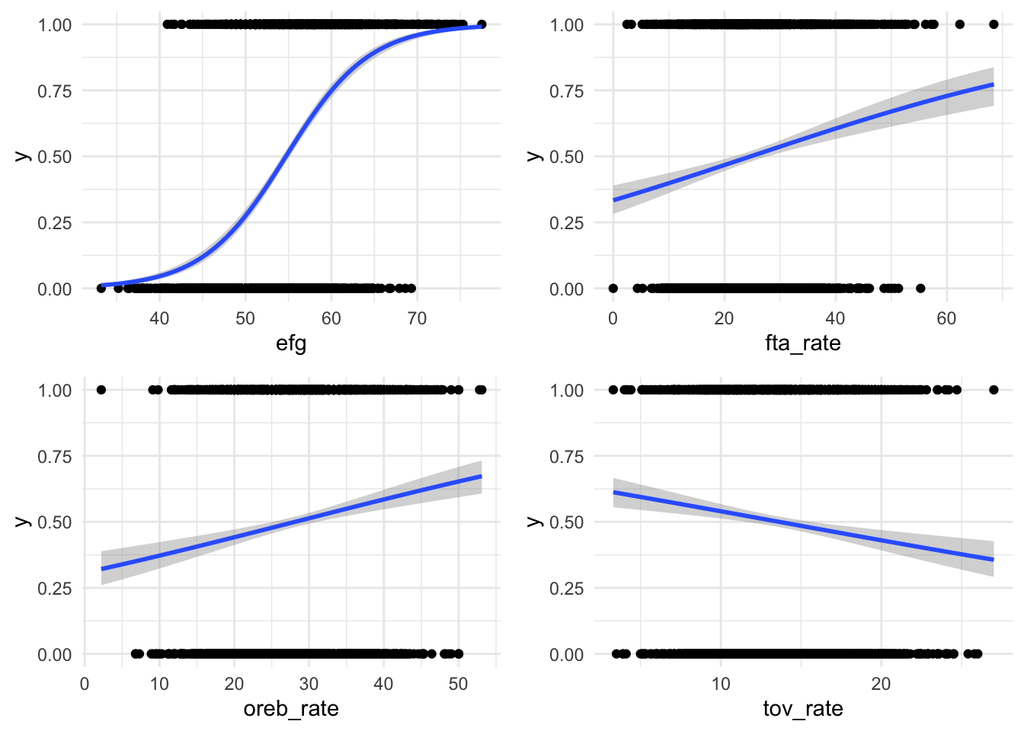

```r
p1 = ggplot(df, aes(x = efg, y = y)) +
geom_point() +
geom_smooth(method = 'glm', method.args = list(family = binomial)) +
theme_minimal()

p2 = ggplot(df, aes(x = fta_rate, y = y)) +
geom_point() +
geom_smooth(method = 'glm', method.args = list(family = binomial)) +
theme_minimal()

p3 = ggplot(df, aes(x = oreb_rate, y = y)) +
geom_point() +
geom_smooth(method = 'glm', method.args = list(family = binomial)) +
theme_minimal()

p4 = ggplot(df, aes(x = tov_rate, y = y)) +
geom_point() +
geom_smooth(method = 'glm', method.args = list(family = binomial)) +
theme_minimal()

grid.arrange(p1, p2, p3, p4, ncol = 2, nrow =2)
```

```r
null = glm(y ~ 1, family = 'binomial', data = df)
full = glm(y ~., family = 'binomial', data = df)
coef_table = round(summary(full)$coef, 3)
add_info = full %>%
  broom::glance() %>%
  round(2) %>% t()

coef_table %>% kbl %>% kable_styling()
```

|  | Estimate | Std. Error | z value | Pr(>\|z\|) |
| --- | --- | --- | --- | --- |
| (Intercept) | 0.000 | 1.498 | 0.000 | 1 |
| efg | 0.942 | 0.056 | 16.961 | 0 |
| oreb_rate | 0.370 | 0.026 | 14.121 | 0 |
| tov_rate | -0.764 | 0.054 | -14.262 | 0 |
| fta_rate | 0.156 | 0.015 | 10.225 | 0 |
| opp_efg | -0.942 | 0.056 | -16.961 | 0 |
| opp_oreb_rate | -0.370 | 0.026 | -14.121 | 0 |
| opp_tov_rate | 0.764 | 0.054 | 14.262 | 0 |
| opp_fta_rate | -0.156 | 0.015 | -10.225 | 0 |

```r
tab_model(full, transform = NULL)
```

|  | y |  |  |
| --- | --- | --- | --- |
| Predictors | Log-Odds | CI | p |
| (Intercept) | 0.00 | -2.94 – 2.94 | 1.000 |
| efg | 0.94 | 0.84 – 1.06 | **<0.001** |
| oreb rate | 0.37 | 0.32 – 0.42 | **<0.001** |
| tov rate | -0.76 | -0.87 – -0.66 | **<0.001** |
| fta rate | 0.16 | 0.13 – 0.19 | **<0.001** |
| opp efg | -0.94 | -1.06 – -0.84 | **<0.001** |
| opp oreb rate | -0.37 | -0.42 – -0.32 | **<0.001** |
| opp tov rate | 0.76 | 0.66 – 0.87 | **<0.001** |
| opp fta rate | -0.16 | -0.19 – -0.13 | **<0.001** |
| Observations | 2446 |  |  |
| R<sup>2</sup> Tjur | 0.862 |  |  |

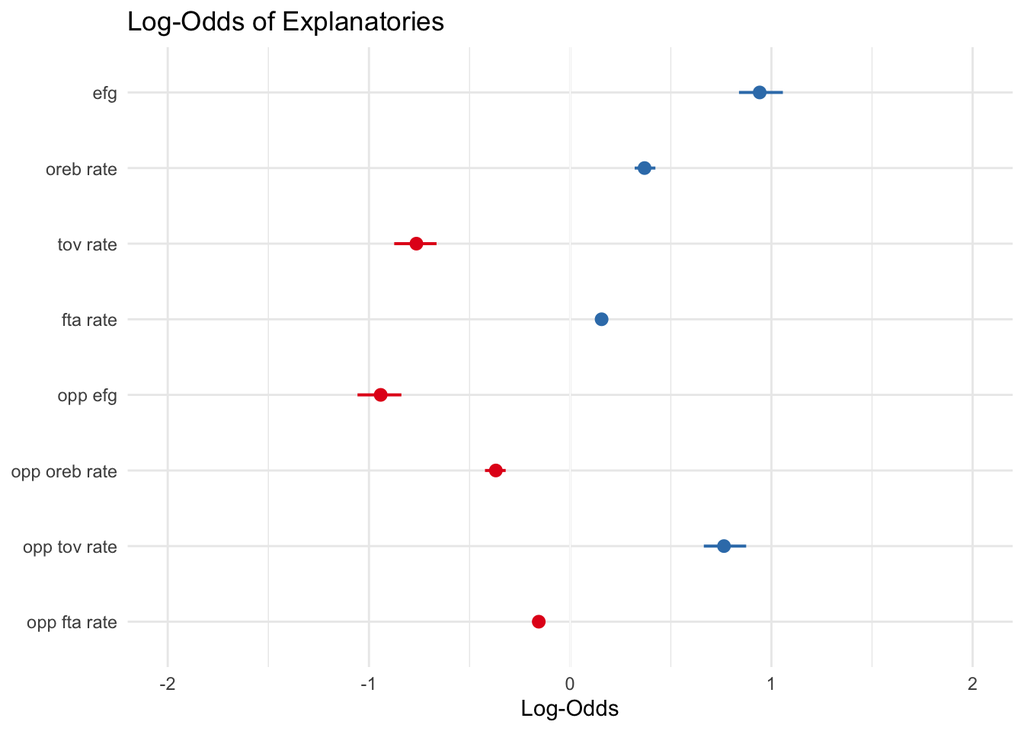

```r
plot_model(full, transform = NULL) + labs(title= "Log-Odds of Explanatories") + theme_minimal()
```

### Evaluating Performance

**In-Sample Performance**

Loss: 0 Win: 1

```r
df = df %>%
  mutate(pred_prob = predict(full, type = 'response'),
         pred_win = round(pred_prob))

cm = confusionMatrix(
  data = as.factor(df$pred_win),
  reference = as.factor(df$y))

cm$table %>% kbl() %>% kable_styling() %>%
  add_header_above(c('Prediction' = 1, 'Truth' = 2))
```

| Prediction | Truth 0 | Truth 1 |
| --- | --- | --- |
| 0 | 1160 | 63 |
| 1 | 63 | 1160 |

```r
table1 = head(cm$overall, -3)
table1%>% kbl() %>% kable_styling()
```

|  | x |
| --- | --- |
| Accuracy | 0.9484873 |
| Kappa | 0.8969747 |
| AccuracyLower | 0.9389716 |
| AccuracyUpper | 0.9569099 |

**Out of Sample Performance - 10-fold Cross Validation**

```r
x = train(factor(y) ~ efg + oreb_rate + tov_rate + fta_rate + opp_efg + opp_oreb_rate + opp_tov_rate + opp_fta_rate, data = df,
  method = 'glm', family = 'binomial',
  trControl = trainControl(
    method = 'cv', number = 10, verboseIter = FALSE))
x = x$results[,-1]
x %>%
  kbl() %>%
  kable_styling()
```

| Accuracy | Kappa | AccuracySD | KappaSD |
| --- | --- | --- | --- |
| 0.9472683 | 0.894533 | 0.0190768 | 0.0381549 |

### Interpretation & Final Model

**Final Model**:

$\log(\frac{p}{1-p}) = 0.942(\text{efg\%}) + 0.37(\text{oreb\_rate}) - 0.764(\text{tov\_rate}) + 0.156(\text{fta\_rate})$

$\qquad- 0.942(\text{opp\_efg\%}) - 0.37(\text{opp\_oreb\_rate}) + 0.764(\text{opp\_tov\_rate}) - 0.156(\text{opp\_fta\_rate})$

Each coefficient represents the expected change in the log-odds of winning for a one-unit increase in the associated variable, while holding all other variables constant.

The model shows that this combination of explanatory variables while limiting the opponent’s effectiveness in the same areas, collectively determine your probability of winning a basketball game. Clearly the most significant predictor in the outcome of a basketball game is how well you shoot.

### Improvements

**Separating Variables** In an ANOVA, under General Team Analysis > Shooting > Impact of Possession Initiation of Efficient Field Goal Percent, it was proved that how a possession begins results in a significantly different efficient shooting percentage. Hence, a revised model distinguish efg as the results only those possession that came off ‘make’, ‘miss’ and ‘dead_ball’. oreb_rate would become oreb_rate * oreb_efg. tov_rate would become tov_rate * 1{efg_live_tov} (an indicator function). And fta_rate would become fta_rate * ft% to account for foul rates being high if the opposing team is purposefully fouling poor free throw shooters.